# Una prima analisi sul dataset ‘Sara_dataset’

Author

Marco Foda

Published

March 18, 2026

# 1 Cominciamo!

## 1.1 Summary del dataset, per vedere se è tutto ok

Utilizziamo la library readxl (Wickham and Bryan 2025) per leggere il dataset da Excel.

```r
library(readxl)
dsara <- read_excel("Quarto_ARCA/Templates/html/Sara_dataset.xls")
summary(dsara)
```

```
     gender         major           cond          phobia         prevmath
 Min.   :1.00   Min.   :1.00   Min.   :1.00   Min.   : 0.00   Min.   :0.00
 1st Qu.:1.00   1st Qu.:1.00   1st Qu.:1.75   1st Qu.: 1.00   1st Qu.:1.00
 Median :1.00   Median :2.00   Median :2.50   Median : 3.00   Median :1.00
 Mean   :1.43   Mean   :2.52   Mean   :2.50   Mean   : 3.31   Mean   :1.38
 3rd Qu.:2.00   3rd Qu.:3.25   3rd Qu.:3.25   3rd Qu.: 4.00   3rd Qu.:2.00
 Max.   :2.00   Max.   :5.00   Max.   :4.00   Max.   :10.00   Max.   :6.00

    mathquiz        statquiz        hr_base          hr_pre         hr_post
 Min.   : 9.00   Min.   : 1.00   Min.   :64.00   Min.   :62.00   Min.   :64.0
 1st Qu.:22.00   1st Qu.: 6.00   1st Qu.:70.00   1st Qu.:70.00   1st Qu.:69.0
 Median :30.00   Median : 7.00   Median :72.00   Median :74.00   Median :73.0
 Mean   :29.07   Mean   : 6.86   Mean   :72.27   Mean   :73.85   Mean   :72.8
 3rd Qu.:35.00   3rd Qu.: 8.00   3rd Qu.:74.00   3rd Qu.:78.00   3rd Qu.:76.0
 Max.   :49.00   Max.   :10.00   Max.   :80.00   Max.   :87.00   Max.   :86.0
 NA's   :15
    anx_base        anx_pre         anx_post
 Min.   :10.00   Min.   : 8.00   Min.   : 9.0
 1st Qu.:16.00   1st Qu.:14.00   1st Qu.:16.0
 Median :18.00   Median :19.00   Median :19.0
 Mean   :18.43   Mean   :19.58   Mean   :19.4
 3rd Qu.:20.00   3rd Qu.:25.00   3rd Qu.:22.0
 Max.   :39.00   Max.   :39.00   Max.   :40.0
```

Dal summary notiamo che le prime 3 variabili, che dovrebbero essere categoriali, sono quantitative (dato che calcolano media e i 3 quartili), e non dovrebbe essere così. Rendiamole quindi categoriali:

```r
mydsara <- dsara #è buona pratica creare un altro dataset identico per non modificare l'originale
mydsara$gender <- factor(mydsara$gender, levels=c(1,2), labels=c("F","M"))
mydsara$major <- factor(mydsara$major, levels=(1:5))
mydsara$cond <- factor(mydsara$cond, levels=(1:4))
#Riguardiamo per vedere cos'è cambiato
summary(mydsara[,1:3])
```

```
 gender major  cond
 F:57   1:29   1:25
 M:43   2:25   2:25
        3:21   3:25
        4:15   4:25
        5:10
```

# 2 Analisi descrittiva

Guardiamo prima di tutto come sono distribuite le variabili categoriali tramite la funzione table. In particolare, è interessante vedere se i due gender sono equamente distribuiti tra le diverse condizioni sperimentali.  
Tramite questa funzione, osserviamo le frequenze relative (dove il totale è per riga) di maschi e femmine tra le varie condizioni sperimentali:

```r
round(prop.table(table(mydsara$gender, mydsara$cond), margin=1),2 )
```

```
       1    2    3    4
  F 0.28 0.26 0.16 0.30
  M 0.21 0.23 0.37 0.19
```

Da questo notiamo che le femmine si trovano principalmente (58%) in condizioni più “estreme”, facili o impossibili, mentre i maschi sono distribuiti maggiormente (60%) in condizioni “medie”. Data questa differenza, ci aspettiamo maggiore variabilità post-test nelle femmine rispetto ai maschi, verifichiamolo:

```r
sd(mydsara[mydsara$gender=="M",]$anx_post)
```

```
[1] 5.06765
```

```r
sd(mydsara[mydsara$gender=="F",]$anx_post)
```

```
[1] 3.534202
```

A questo punto, è interessante osservare anche tramite dei grafici se ci sono differenze nell’ansia di base, pre, e post test tra i due gender.

[figure not shown]

```r
par(mfrow=c(1,3))
boxplot(anx_base ~ gender, data=mydsara)
boxplot(anx_pre ~ gender, data=mydsara)
boxplot(anx_post ~ gender, data=mydsara)
```

Visto quanto diminuisce la IQR tra il pre (secondo grafico) e il post (terzo grafico), possiamo dire che la variabilità iniziale (dovuta probabilmente alle condizioni sperimentali differenti), tende a diminuire e stabilizzarsi dopo il test. Nonostante ciò, l’ansia post test rimane comunque più alta dell’ansia base.

# 3 Correlazioni tra variabili

A questo punto, risulta interessante scoprire se l’ansia pre-test possa essere predittiva del risultato al math quiz:

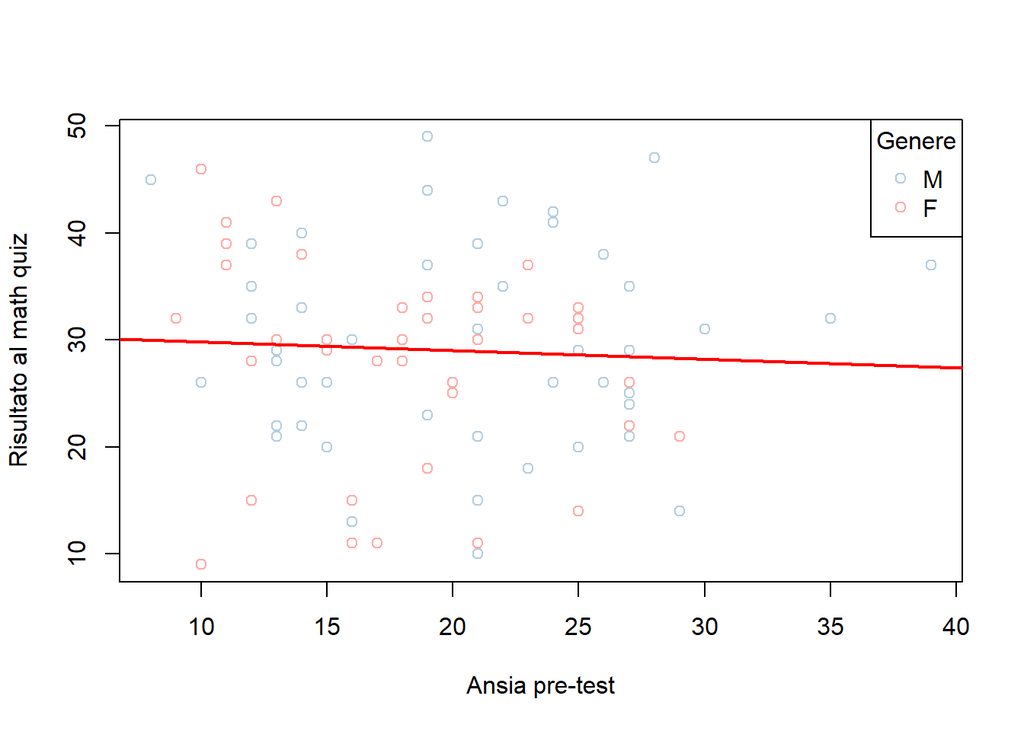

```r
leg_colori<- ifelse(mydsara$gender == "M", "#b3cde0", "#ffaaa5")
plot(mydsara$anx_pre,mydsara$mathquiz, col = leg_colori, xlab="Ansia pre-test", ylab="Risultato al math quiz")
legend("topright", legend = c("M", "F"),  col = c("#b3cde0", "#ffaaa5"), pch = 1, title = "Genere")

risultati_premat <- cor.test(mydsara$anx_pre, mydsara$mathquiz)
cor_premat <- round(risultati_premat$estimate,3)
pvalue_premat <- round(risultati_premat$p.value,3)
modello <- lm(mathquiz ~ anx_pre, data = mydsara)
abline(modello, col = "red", lwd = 2)
```

Dal grafico si nota che la correlazione tra ansia pre-test e math_quiz risulta NON essere significativa: $r =$ -0.055 , $p =$ 0.618

[figure not shown]

*… se Altoè vedesse questa immagine non so cosa mi direbbe*

# 4 Conclusioni

**Lati positivi**

- Dopo una breve analisi descrittiva, siamo giunti a una conclusione sensata e interessante: l’ansia pre-test non può essere considerata predittiva dei risultati di un test
- È stato molto divertente

**Lati negativi**

- L’analisi effettuata è molto riduttiva e si è occupata solamente di ansia pre-test e dei risultati del test matematico, senza approfondire ulteriormente le differenze tra genere, major, condizioni, ecc.
- Gemini a volte proprio non ce la fa

## 5 Bibliografia

Wickham, Hadley, and Jennifer Bryan. 2025. “Readxl: Read Excel Files.” https://doi.org/10.32614/CRAN.package.readxl.